# Capability model — parameter sensitivity

Cagliari · ELECTRE TRI-B capability classification · 1563 nodes · perturbation of the user-configured parameters. Figures are the **percentage of nodes that change capability class** unless stated otherwise. Read top to bottom: methodology, exact parameters tested, results section by section, then the conclusions at the end. Robustness to input noise is a separate report — see `robustness_report.py`.

## 1. How this analysis works

### The model chain being tested

The model turns a location into a capability class through five steps, each carrying hand-set numbers that a human chose:

[output not shown]

The question this report answers: **are the chosen values in a stable region, or would small, defensible changes redraw the map?** That is what lets a configuration be defended as *the* model rather than one of many arbitrary ones.

### Sensitivity vs. robustness

**Sensitivity** (sections 4–5 here): *do the parameters matter?* Change a knob, measure how much the output moves. Identifies which numbers are load-bearing (need justification) vs decorative. A separate question, answered in its own report: **robustness** — *is the output trustworthy given noisy inputs?* Holds every parameter fixed and jitters the input service scores instead, to see how often a node keeps its class. A model can be insensitive to parameters yet non-robust to noise, or vice-versa — they are independent, which is why they get independent reports: see `robustness_report.py` (`outputs/sensitivity/robustness_report.html`).

### How the numbers were produced (and why they are trustworthy)

**Upstream parameters** (decay, interactions, capacity, contribution) feed complex accessibility math, so they are *not* re-implemented. Each perturbation writes modified copies of the config CSVs and launches a fresh subprocess that runs the **real** accessibility + service stages from the cached travel times — the exact production code — so the results are about the real model. The original CSVs are backed up and hash-verified on restore, so a run can never leave your config mutated.

**Downstream ELECTRE** is pure arithmetic over the service scores, so it is vectorized for speed, then **validated against the real** `electre_tri_integration()` on sampled nodes before any analysis — the run aborts on any disagreement, so the fast path is provably the real model.

### Metric glossary

| Metric | Meaning |
| --- | --- |
| % nodes changed | Fraction of nodes whose final capability *class* differs from baseline. A node counts only if it crosses a class boundary — so this measures decision changes, which is what matters for a map. |
| mean \|score Δ\| | Average absolute change in the continuous score. Compared with "% changed" it shows *why*: many nodes flipped with a small Δ = they sat on a knife-edge. |
| mean \|service Δ\| | Same, per individual service — traces which of the 11 services a perturbation actually moves. |
| node dropout | Nodes that vanish because a parameter change leaves them with zero reachable POIs — itself a sensitivity signal. |

## 2. Parameters tested

Every value below was actually run through the real model (upstream) or the validated vectorized ELECTRE (downstream) — nothing here is a plan, it is what produced the results in sections 3–6.

### Upstream config perturbations (real accessibility + service stages re-run)

| Parameter | Config file | Values tested |
| --- | --- | --- |
| `decay_coefficient` | poi_types.csv | scaled by 0.8 (shorter travel tolerance) |
| `decay_coefficient` | poi_types.csv | scaled by 1.2 (longer travel tolerance) |
| `contribution_coefficient` | services.csv | every POI type set to the minimum tier (1: saturates after 1 POI) |
| `contribution_coefficient` | services.csv | every POI type set to the maximum tier (8: needs 8 POIs to saturate) |
| `choquet_capacity` | services.csv | blended 50% toward uniform (less skewed) |
| `choquet_capacity` | services.csv | deviations from uniform exaggerated 50% (more skewed) |
| `choquet_interactions` | poi_types.csv | all defined pairs set to 0 (no interactions) |
| `choquet_interactions` | poi_types.csv | all defined pairs set to 0.7 (maximal interactions), sign preserved from baseline |

### Downstream ELECTRE TRI-B OAT sweeps (one parameter at a time, others at baseline)

| Parameter | Baseline | Values tested |
| --- | --- | --- |
| `q_factor` | 0.25 | 0.2, 0.25, 0.3 |
| `p_factor` | 0.75 | 0.65, 0.75, 0.85 |
| `lambda` | 0.65 | 0.6, 0.65, 0.7 |

### Weight perturbation

Dirichlet draws around the configured (uniform) service weights, 200 draws per capability, concentration high enough that draws stay close to uniform (max single weight observed: 0.72).

Robustness to input noise (Monte Carlo over gaussian-perturbed service scores) is a separate analysis -- see the robustness report (`robustness_report.py`).

## 3. Upstream config sensitivity

Each configuration re-runs the real accessibility + service stages from the cached travel times, changing one user-config quantity one step below and one step above its baseline (section 2). % of nodes changing final capability class vs the pristine config:

| capability config | care | nutrition | restorativeness |
| --- | --- | --- | --- |
| capacity_blend50 | 4.93 | 1.41 | 1.92 |
| capacity_exaggerate50 | 23.86 | 18.92 | 13.28 |
| contribution_max | 44.13 | 12.06 | 6.03 |
| contribution_min | 42.08 | 33.93 | 24.70 |
| decay_x0.8 | 35.92 | 30.66 | 13.79 |
| decay_x1.2 | 33.68 | 40.03 | 27.20 |
| interactions_0 | 3.13 | 1.54 | 0.70 |
| interactions_x0.7 | 34.06 | 23.09 | 86.40 |

Same data as a tornado plot per axis — the below-baseline config's effect extends left, the above-baseline config's extends right, one row per capability:

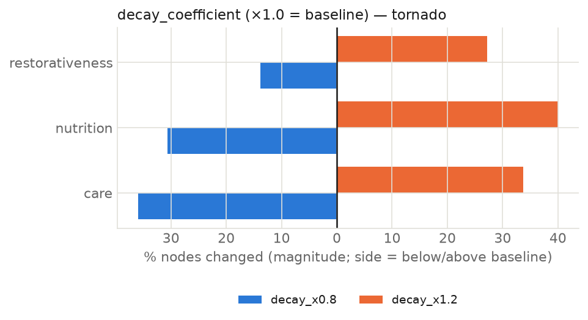

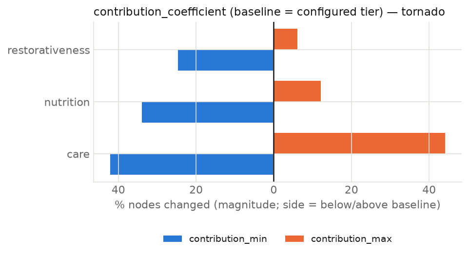

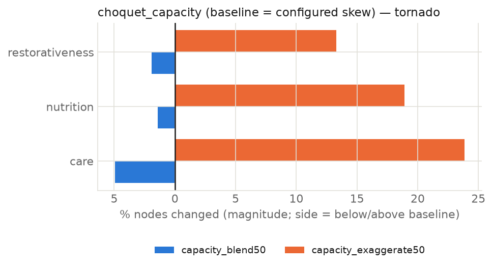

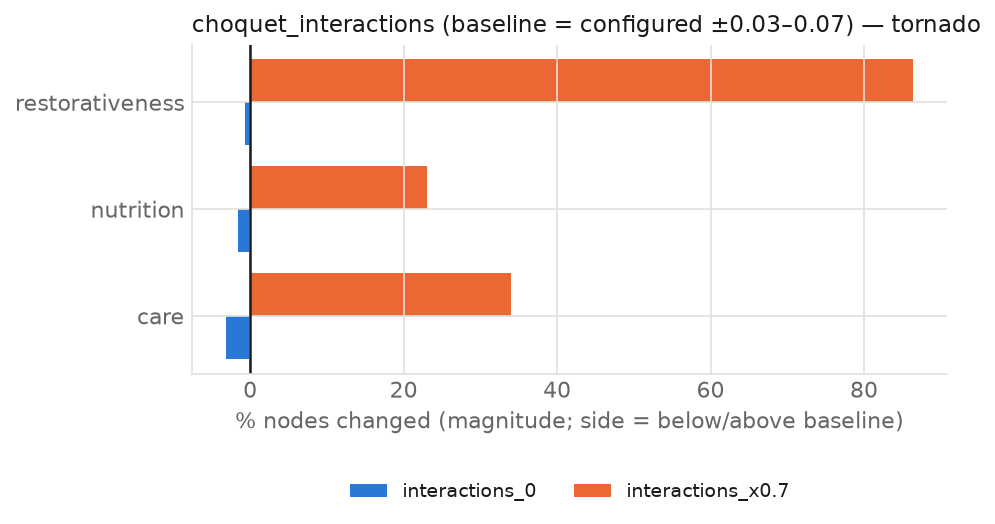

Where each perturbation acts — mean |service-score Δ| vs baseline (larger = that service moves more). This localizes the sensitivity: contribution changes concentrate in the diagnostic/rehabilitation services, while decay spreads across every service because it touches every POI type.

| service config | care_services | cultural_activities | diagnosis_and_prevention | eating_out | emergency_services | food_access | impatient_and_rehabilitation | medicines_and_supplies | nature_contact | quietness | scenic_views | sport_and_movement |
| --- | --- | --- | --- | --- | --- | --- | --- | --- | --- | --- | --- | --- |
| capacity_blend50 | 0.02 | 0.00 | 0.00 | 0.00 | 0.00 | 0.01 | 0.01 | 0.01 | 0.01 | 0.03 | 0.00 | 0.00 |
| capacity_exaggerate50 | 0.02 | 0.04 | 0.04 | 0.04 | 0.03 | 0.04 | 0.05 | 0.03 | 0.03 | 0.01 | 0.02 | 0.04 |
| contribution_max | 0.04 | 0.02 | 0.06 | 0.03 | 0.10 | 0.03 | 0.02 | 0.03 | 0.01 | 0.05 | 0.01 | 0.02 |
| contribution_min | 0.18 | 0.07 | 0.17 | 0.07 | 0.03 | 0.07 | 0.19 | 0.05 | 0.04 | 0.16 | 0.03 | 0.05 |
| decay_x0.8 | 0.05 | 0.05 | 0.06 | 0.05 | 0.04 | 0.06 | 0.05 | 0.05 | 0.03 | 0.04 | 0.02 | 0.05 |
| decay_x1.2 | 0.08 | 0.07 | 0.07 | 0.07 | 0.04 | 0.09 | 0.07 | 0.07 | 0.04 | 0.05 | 0.03 | 0.07 |
| interactions_0 | 0.02 | 0.00 | 0.01 | 0.01 | 0.00 | 0.00 | 0.01 | 0.00 | 0.00 | 0.01 | 0.00 | 0.00 |
| interactions_x0.7 | 0.02 | 0.04 | 0.04 | 0.01 | 0.01 | 0.07 | 0.14 | 0.02 | 0.03 | 0.36 | 0.01 | 0.78 |

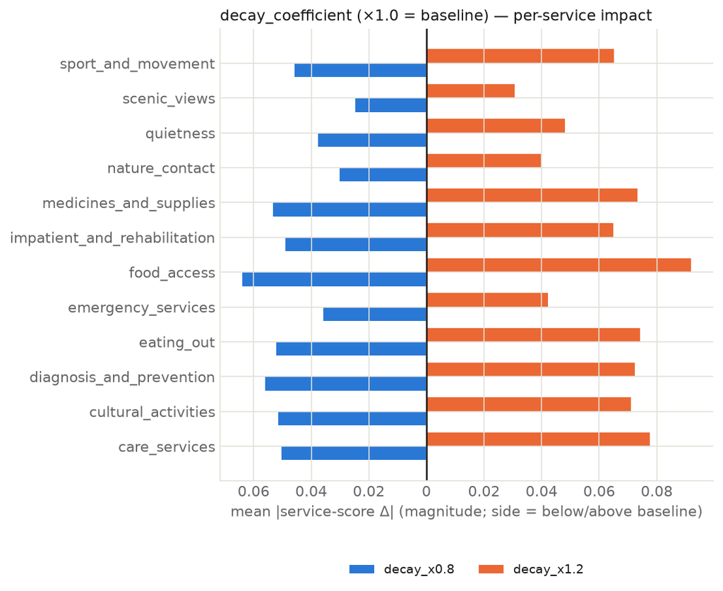

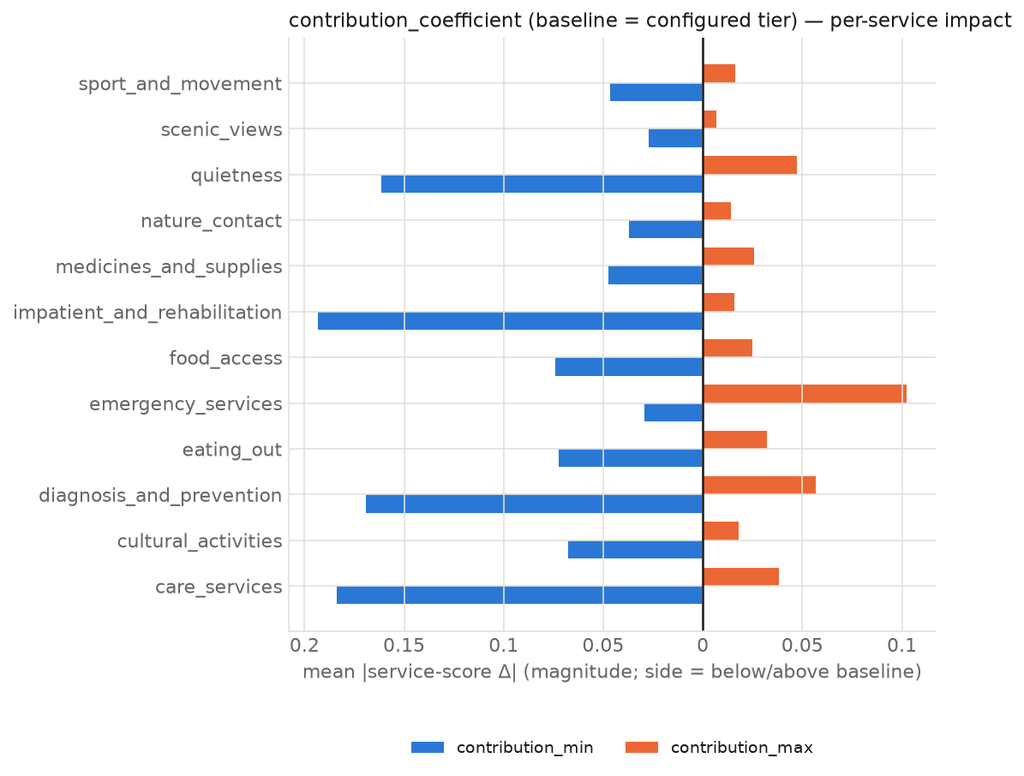

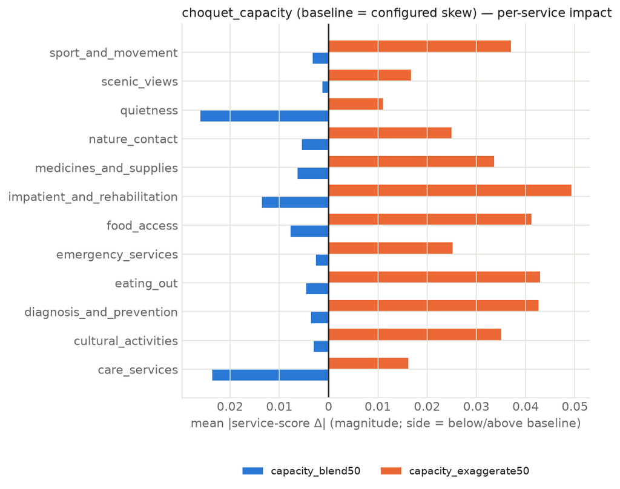

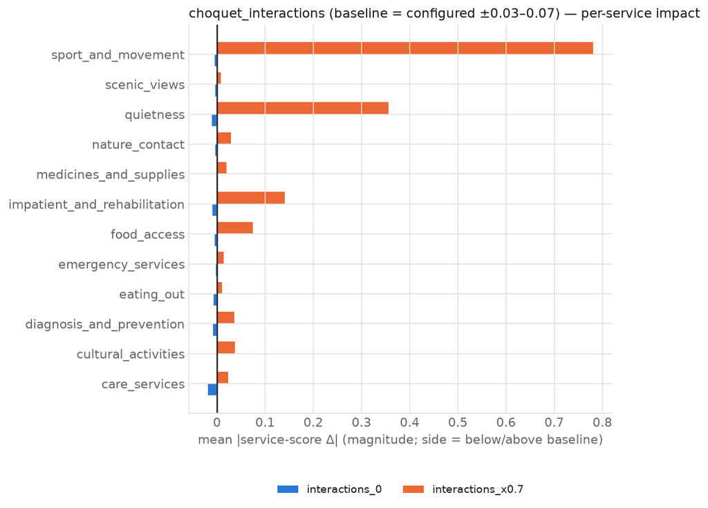

Reachable-node changes (a node dropping out because it loses all POIs is itself a sensitivity signal):

| config | n_nodes | dropped_vs_baseline | added_vs_baseline |
| --- | --- | --- | --- |
| decay_x0.8 | 1559 | 4 | 0 |
| decay_x1.2 | 1559 | 4 | 0 |
| interactions_0 | 1563 | 0 | 0 |
| interactions_x0.7 | 1559 | 4 | 0 |
| capacity_blend50 | 1563 | 0 | 0 |
| capacity_exaggerate50 | 1559 | 4 | 0 |
| contribution_min | 1559 | 4 | 0 |
| contribution_max | 1559 | 4 | 0 |

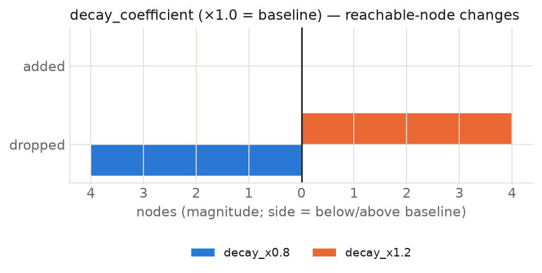

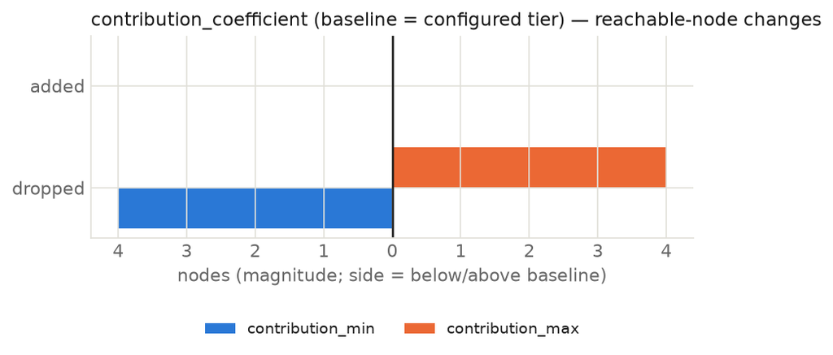

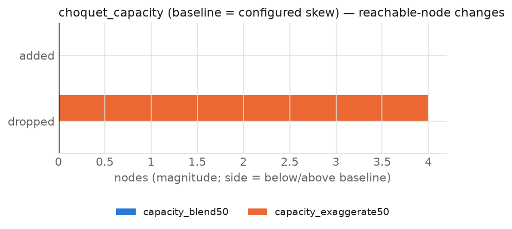

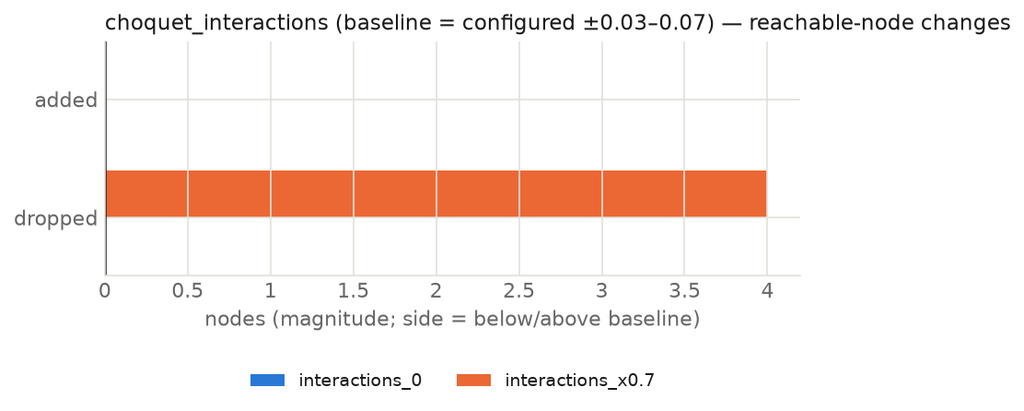

## 4. Downstream ELECTRE parameter sweeps (OAT)

One parameter at a time, all others at baseline, tested at exactly one value below and one value above baseline (section 2) — a direct local sensitivity check rather than a full curve. % of nodes changing class vs baseline (0% at baseline). The tornado plots below put the baseline value in the centre row; bars extend left for the below-baseline value and right for the above-baseline value, so **an asymmetric shape (one side much longer than the other) is itself the finding** — it means the model responds differently to tightening vs loosening that parameter right around its current value.

### q_factor (baseline 0.25) — near-symmetric

Nudging q_factor one step either side of baseline moves at most ~3% of care, and both directions respond similarly: the baseline is not sitting on an edge.

| capability value | care | nutrition | restorativeness |
| --- | --- | --- | --- |
| 0.20 | 3.20 | 0.26 | 0.38 |
| 0.25 | 0.00 | 0.00 | 0.00 |
| 0.30 | 3.20 | 0.06 | 0.32 |

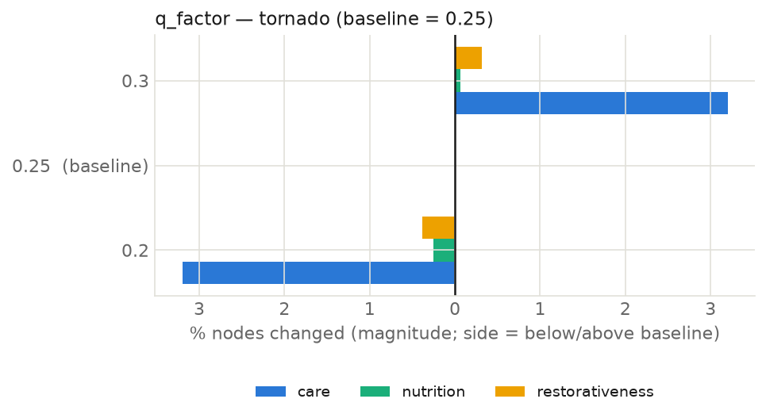

### p_factor (baseline 0.75) — near-symmetric

Same benign signature (up to ~4% of care for the immediate neighbor on either side). Baseline sits in a safe local neighborhood.

| capability value | care | nutrition | restorativeness |
| --- | --- | --- | --- |
| 0.65 | 4.03 | 1.22 | 1.79 |
| 0.75 | 0.00 | 0.00 | 0.00 |
| 0.85 | 4.29 | 1.22 | 1.54 |

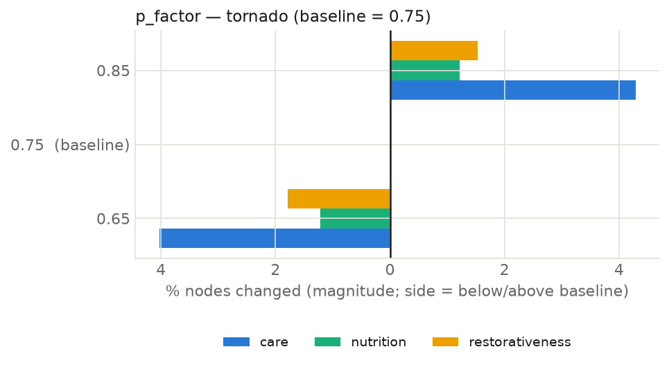

### λ cut level (baseline 0.65) — asymmetric

| capability value | care | nutrition | restorativeness |
| --- | --- | --- | --- |
| 0.60 | 8.89 | 0.96 | 18.55 |
| 0.65 | 0.00 | 0.00 | 0.00 |
| 0.70 | 10.36 | 0.90 | 2.56 |

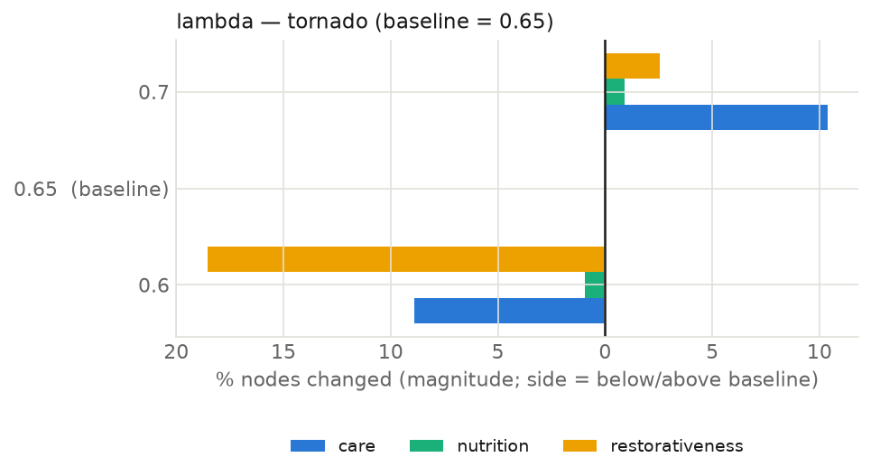

## 5. Weight perturbation (Dirichlet around configured weights)

Randomly perturbs the ELECTRE service weights around their configured values. Read the **max** column: a typical draw moves only a few percent of care nodes (the median), but some draws move a large share — so the weight assumption is mostly harmless yet occasionally consequential for care.

| capability | mean | std | 50% | max |
| --- | --- | --- | --- | --- |
| care | 8.33 | 11.90 | 5.37 | 65.26 |
| nutrition | 1.21 | 4.25 | 0.64 | 35.51 |
| restorativeness | 4.44 | 6.75 | 1.54 | 21.05 |

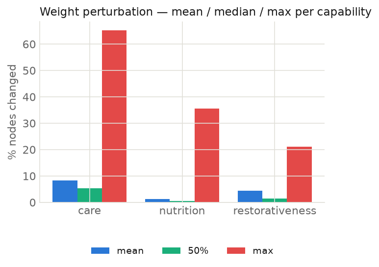

## 6. Capability-level shift under min/max perturbation

Every earlier section measures *whether a node's class changed*. This section instead asks: under each parameter's min and max test (section 2), **what share of nodes ends up at each of the five ELECTRE classes** (Very Low .. Very High)? One tornado plot per capability × class: the parameter name labels the left axis, the exact (min, max) value or procedure tested labels the right axis, and each bar shows the % of nodes at that class under the min test (left, blue) or the max test (right, orange).

### care

#### Very Low

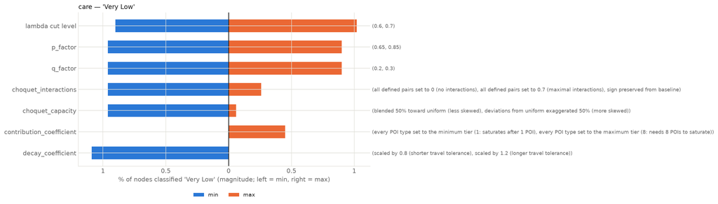

#### Low

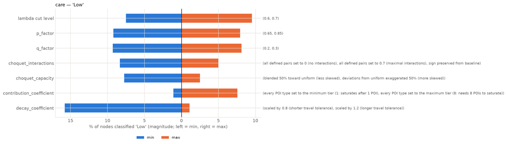

#### Medium

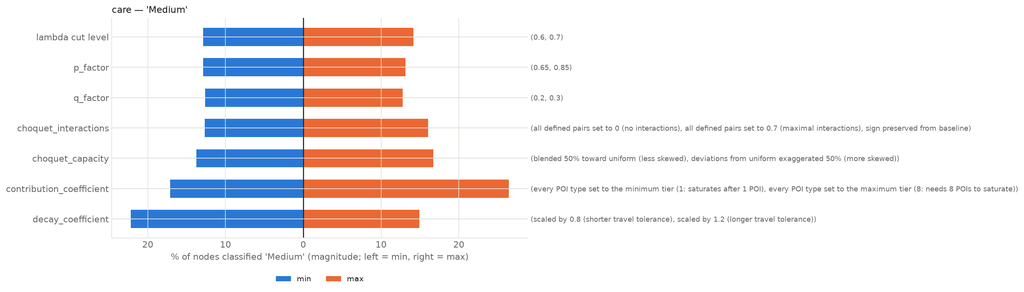

#### High

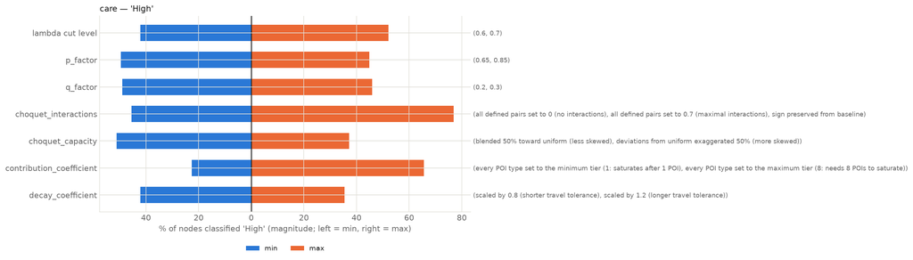

#### Very High

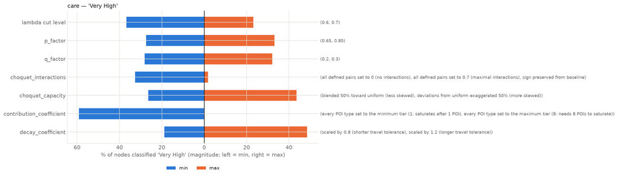

### nutrition

#### Very Low

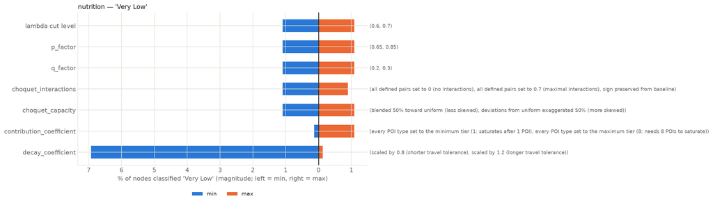

#### Low

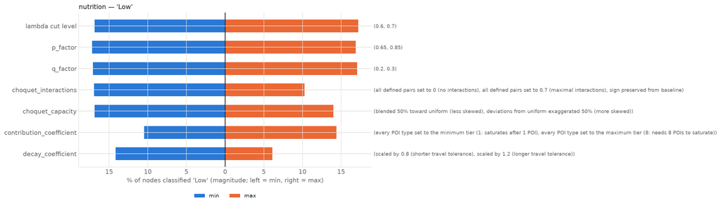

#### Medium

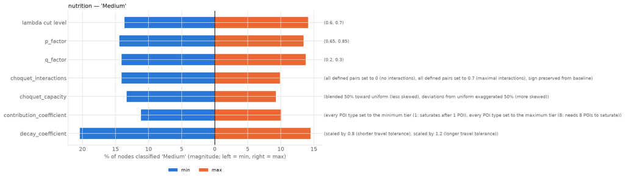

#### High

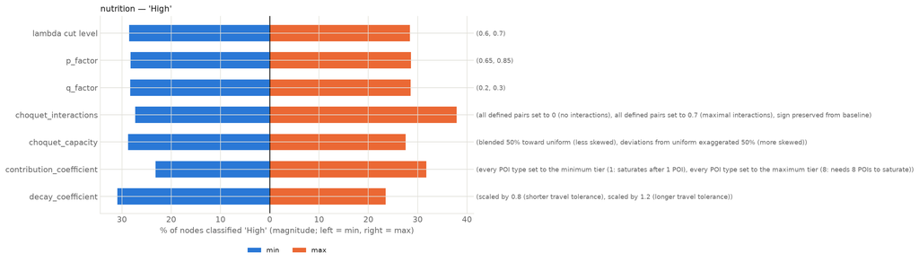

#### Very High

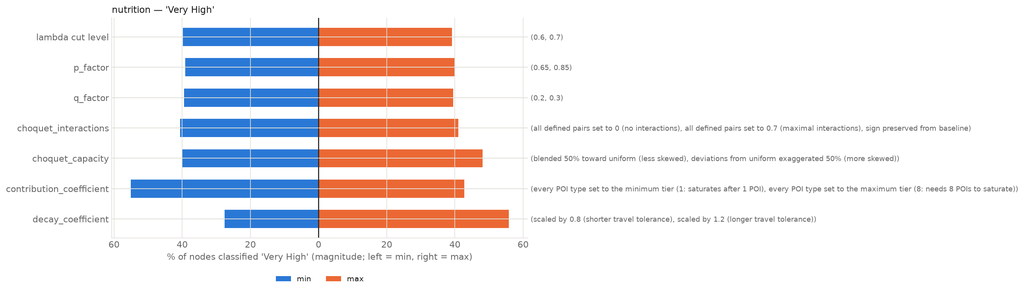

### restorativeness

#### Very Low

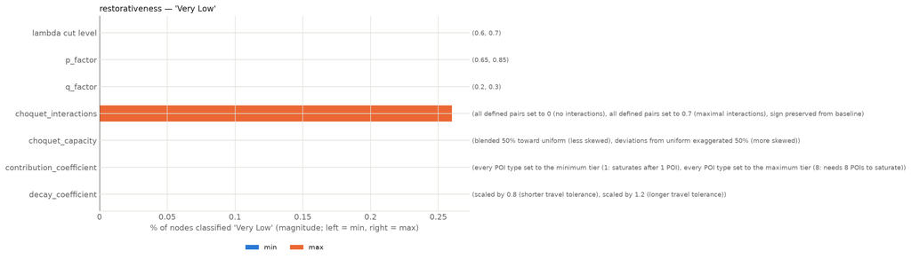

#### Low

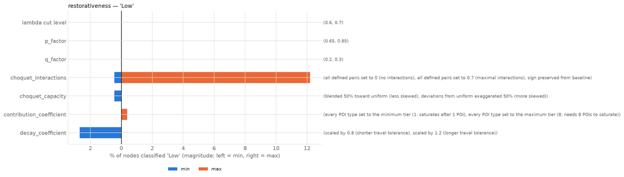

#### Medium

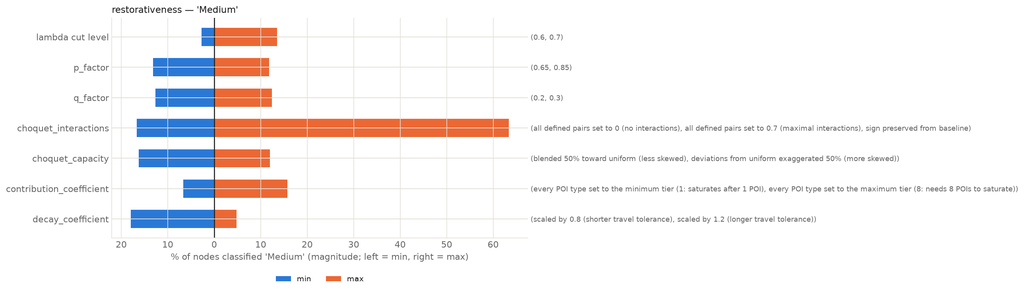

#### High

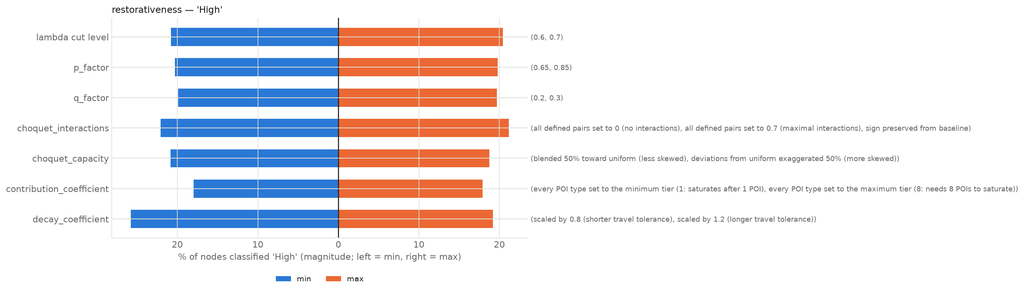

#### Very High

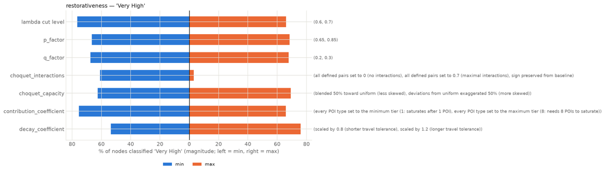

### Comprehensive table

Every number behind the charts above, one row per capability × class × parameter:

| Capability | Level | Parameter | Min (test) | % nodes (min) | Max (test) | % nodes (max) |
| --- | --- | --- | --- | --- | --- | --- |
| care | Very Low | decay_coefficient | scaled by 0.8 (shorter travel tolerance) | 1.1% | scaled by 1.2 (longer travel tolerance) | 0.0% |
| care | Very Low | contribution_coefficient | every POI type set to the minimum tier (1: saturates after 1 POI) | 0.0% | every POI type set to the maximum tier (8: needs 8 POIs to saturate) | 0.5% |
| care | Very Low | choquet_capacity | blended 50% toward uniform (less skewed) | 1.0% | deviations from uniform exaggerated 50% (more skewed) | 0.1% |
| care | Very Low | choquet_interactions | all defined pairs set to 0 (no interactions) | 1.0% | all defined pairs set to 0.7 (maximal interactions), sign preserved from baseline | 0.3% |
| care | Very Low | q_factor | 0.2 | 1.0% | 0.3 | 0.9% |
| care | Very Low | p_factor | 0.65 | 1.0% | 0.85 | 0.9% |
| care | Very Low | lambda cut level | 0.6 | 0.9% | 0.7 | 1.0% |
| care | Low | decay_coefficient | scaled by 0.8 (shorter travel tolerance) | 15.8% | scaled by 1.2 (longer travel tolerance) | 1.1% |
| care | Low | contribution_coefficient | every POI type set to the minimum tier (1: saturates after 1 POI) | 1.1% | every POI type set to the maximum tier (8: needs 8 POIs to saturate) | 7.6% |
| care | Low | choquet_capacity | blended 50% toward uniform (less skewed) | 7.7% | deviations from uniform exaggerated 50% (more skewed) | 2.5% |
| care | Low | choquet_interactions | all defined pairs set to 0 (no interactions) | 8.3% | all defined pairs set to 0.7 (maximal interactions), sign preserved from baseline | 5.0% |
| care | Low | q_factor | 0.2 | 9.3% | 0.3 | 8.1% |
| care | Low | p_factor | 0.65 | 9.2% | 0.85 | 7.9% |
| care | Low | lambda cut level | 0.6 | 7.5% | 0.7 | 9.5% |
| care | Medium | decay_coefficient | scaled by 0.8 (shorter travel tolerance) | 22.2% | scaled by 1.2 (longer travel tolerance) | 14.9% |
| care | Medium | contribution_coefficient | every POI type set to the minimum tier (1: saturates after 1 POI) | 17.1% | every POI type set to the maximum tier (8: needs 8 POIs to saturate) | 26.4% |
| care | Medium | choquet_capacity | blended 50% toward uniform (less skewed) | 13.8% | deviations from uniform exaggerated 50% (more skewed) | 16.7% |
| care | Medium | choquet_interactions | all defined pairs set to 0 (no interactions) | 12.7% | all defined pairs set to 0.7 (maximal interactions), sign preserved from baseline | 16.0% |
| care | Medium | q_factor | 0.2 | 12.6% | 0.3 | 12.8% |
| care | Medium | p_factor | 0.65 | 12.9% | 0.85 | 13.1% |
| care | Medium | lambda cut level | 0.6 | 12.9% | 0.7 | 14.1% |
| care | High | decay_coefficient | scaled by 0.8 (shorter travel tolerance) | 42.1% | scaled by 1.2 (longer travel tolerance) | 35.4% |
| care | High | contribution_coefficient | every POI type set to the minimum tier (1: saturates after 1 POI) | 22.6% | every POI type set to the maximum tier (8: needs 8 POIs to saturate) | 65.5% |
| care | High | choquet_capacity | blended 50% toward uniform (less skewed) | 51.2% | deviations from uniform exaggerated 50% (more skewed) | 37.1% |
| care | High | choquet_interactions | all defined pairs set to 0 (no interactions) | 45.5% | all defined pairs set to 0.7 (maximal interactions), sign preserved from baseline | 76.9% |
| care | High | q_factor | 0.2 | 49.1% | 0.3 | 46.0% |
| care | High | p_factor | 0.65 | 49.6% | 0.85 | 44.9% |
| care | High | lambda cut level | 0.6 | 42.1% | 0.7 | 52.1% |
| care | Very High | decay_coefficient | scaled by 0.8 (shorter travel tolerance) | 18.9% | scaled by 1.2 (longer travel tolerance) | 48.6% |
| care | Very High | contribution_coefficient | every POI type set to the minimum tier (1: saturates after 1 POI) | 59.1% | every POI type set to the maximum tier (8: needs 8 POIs to saturate) | 0.0% |

[output cut: 75 more lines]

## 7. Why care is the fragile capability

- It aggregates more services than the others, so it has more moving parts.
- Its services include the longest travel-time tolerances (up to 45-minute half-times), so they are maximally exposed to the decay and contribution assumptions.
- Empirically, its node scores cluster right at the class boundaries — so a small shift from any of the five stages tips many nodes across a boundary.

The through-line: care is not fragile because of one bad parameter — it is fragile because its scores live on the boundaries, and every parameter can push them over.

## 8. Conclusions

**Ranked by how much they can move a capability's output, these are the parameters that most need an explicit justification.** For every parameter tested, this takes the single worst % of nodes it can flip on *any* of the three capabilities (not just one) — that worst-case exposure is what should drive how much calibration effort a number gets, independent of which capability happens to show it.

### Parameter influence ranking (most to least load-bearing)

Classified automatically at ≥20% = load-bearing, 5–20% = moderate, <5% = inert. "Worst-case %" is the largest effect seen on any capability; "hits hardest" names which one.

| Parameter | Worst-case % nodes changed | Hits hardest | Verdict |
| --- | --- | --- | --- |
| choquet_interactions | 86.4% | restorativeness | load-bearing |
| ELECTRE service weights | 65.3% | care | load-bearing |
| contribution_coefficient | 44.1% | care | load-bearing |
| decay_coefficient | 40.0% | nutrition | load-bearing |
| choquet_capacity | 23.9% | care | load-bearing |
| lambda cut level | 18.6% | restorativeness | moderate |
| p_factor | 4.3% | care | inert |
| q_factor | 3.2% | care | inert |

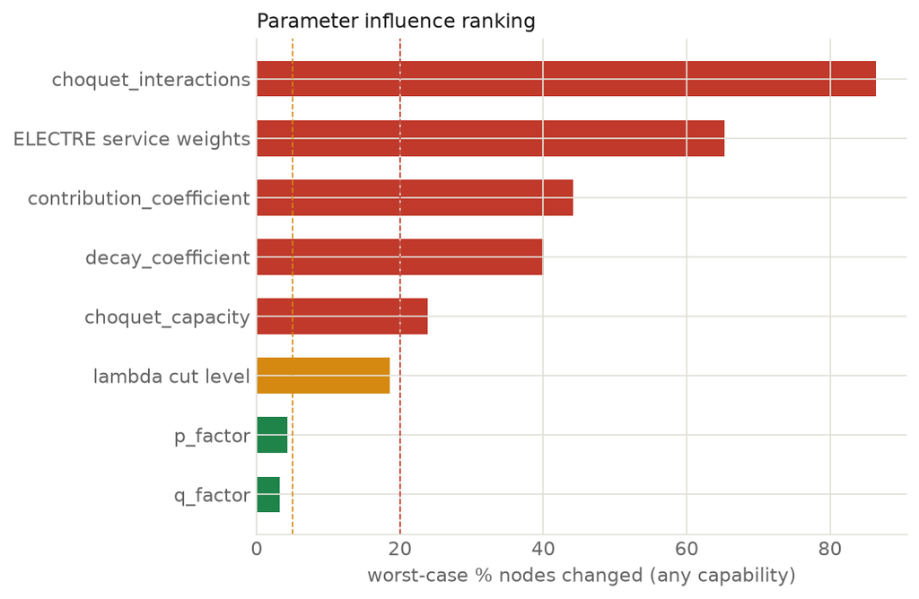

**Read:** the load-bearing parameters at the top must be justified/calibrated for a stable model — they are the ones capable of redrawing the map on their own. The inert ones at the bottom can be set to any defensible value; tuning them is wasted effort.

### Where the load-bearing parameters actually bite

**Care** is the capability most exposed to parameter changes overall — averaged over every perturbation, its share of nodes changing class is: care (27.7%), restorativeness (21.8%), nutrition (20.2%). That is why it appears repeatedly as the "hits hardest" capability above: it is not that one parameter targets care specifically, but that its node scores sit right on the class boundaries (detailed in section 7), so whichever parameter turns out to be load-bearing tends to show its effect there first. Practically: when justifying a load-bearing parameter, check its effect on care first — that is where a bad choice will show up.

### How much to trust the map

That is a separate question from everything above — parameter sensitivity says nothing about whether the output is robust to noise in the inputs. See the robustness report (`robustness_report.py`, `outputs/sensitivity/robustness_report.html`) for that analysis and its QGIS stability layer.

Generated by `sensitivity_report.py` from the analysis CSVs in `outputs/sensitivity/`. Re-running the analyses and this script refreshes every figure and verdict.